# Практикум Осипов

```r
library(reshape2)
library(corrplot)
library(outliers)
library(MASS)
library(ggplot2)
library(boot)
library(nortest)
set.seed(42)
```

Загрузка данных

Данные: Heart Attack dataset - 13 медицинских признаков и колонка о наличии сердечного приступа

Источник: https://www.kaggle.com/datasets/pritsheta/heart-attack

```r
df <- read.csv("Heart_Attack.csv",sep=",",header = TRUE)
```

```r
df
```

| age | sex | cp | trestbps | chol | fbs | restecg | thalach | exang | oldpeak | slope | ca | thal | target |
| --- | --- | --- | --- | --- | --- | --- | --- | --- | --- | --- | --- | --- | --- |
| 63 | 1 | 3 | 145 | 233 | 1 | 0 | 150 | 0 | 2.3 | 0 | 0 | 1 | 1 |
| 37 | 1 | 2 | 130 | 250 | 0 | 1 | 187 | 0 | 3.5 | 0 | 0 | 2 | 1 |
| 41 | 0 | 1 | 130 | 204 | 0 | 0 | 172 | 0 | 1.4 | 2 | 0 | 2 | 1 |
| 56 | 1 | 1 | 120 | 236 | 0 | 1 | 178 | 0 | 0.8 | 2 | 0 | 2 | 1 |
| 57 | 0 | 0 | 120 | 354 | 0 | 1 | 163 | 1 | 0.6 | 2 | 0 | 2 | 1 |
| 57 | 1 | 0 | 140 | 192 | 0 | 1 | 148 | 0 | 0.4 | 1 | 0 | 1 | 1 |
| 56 | 0 | 1 | 140 | 294 | 0 | 0 | 153 | 0 | 1.3 | 1 | 0 | 2 | 1 |
| 44 | 1 | 1 | 120 | 263 | 0 | 1 | 173 | 0 | 0.0 | 2 | 0 | 3 | 1 |
| 52 | 1 | 2 | 172 | 199 | 1 | 1 | 162 | 0 | 0.5 | 2 | 0 | 3 | 1 |
| 57 | 1 | 2 | 150 | 168 | 0 | 1 | 174 | 0 | 1.6 | 2 | 0 | 2 | 1 |

[output cut: 293 more lines]

```r
summary(df)
```

```
      age             sex               cp           trestbps          chol            fbs            restecg          thalach
 Min.   :29.00   Min.   :0.0000   Min.   :0.000   Min.   : 94.0   Min.   :126.0   Min.   :0.0000   Min.   :0.0000   Min.   : 71.0
 1st Qu.:47.50   1st Qu.:0.0000   1st Qu.:0.000   1st Qu.:120.0   1st Qu.:211.0   1st Qu.:0.0000   1st Qu.:0.0000   1st Qu.:133.5
 Median :55.00   Median :1.0000   Median :1.000   Median :130.0   Median :240.0   Median :0.0000   Median :1.0000   Median :153.0
 Mean   :54.37   Mean   :0.6832   Mean   :0.967   Mean   :131.6   Mean   :246.3   Mean   :0.1485   Mean   :0.5281   Mean   :149.6
 3rd Qu.:61.00   3rd Qu.:1.0000   3rd Qu.:2.000   3rd Qu.:140.0   3rd Qu.:274.5   3rd Qu.:0.0000   3rd Qu.:1.0000   3rd Qu.:166.0
 Max.   :77.00   Max.   :1.0000   Max.   :3.000   Max.   :200.0   Max.   :564.0   Max.   :1.0000   Max.   :2.0000   Max.   :202.0
     exang           oldpeak         slope             ca              thal           target
 Min.   :0.0000   Min.   :0.00   Min.   :0.000   Min.   :0.0000   Min.   :0.000   Min.   :0.0000
 1st Qu.:0.0000   1st Qu.:0.00   1st Qu.:1.000   1st Qu.:0.0000   1st Qu.:2.000   1st Qu.:0.0000
 Median :0.0000   Median :0.80   Median :1.000   Median :0.0000   Median :2.000   Median :1.0000
 Mean   :0.3267   Mean   :1.04   Mean   :1.399   Mean   :0.7294   Mean   :2.314   Mean   :0.5446
 3rd Qu.:1.0000   3rd Qu.:1.60   3rd Qu.:2.000   3rd Qu.:1.0000   3rd Qu.:3.000   3rd Qu.:1.0000
 Max.   :1.0000   Max.   :6.20   Max.   :2.000   Max.   :4.0000   Max.   :3.000   Max.   :1.0000
```

1. Реализовать аппроксимацию распределений данных с помощью ядерных оценок.

Распределение количественных признаков

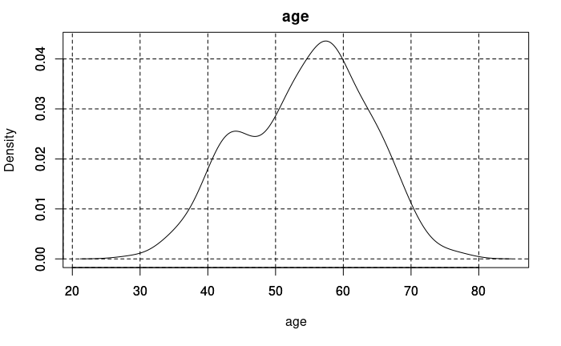

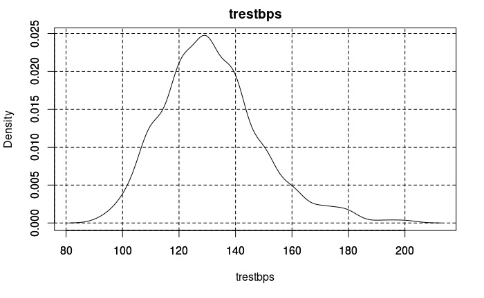

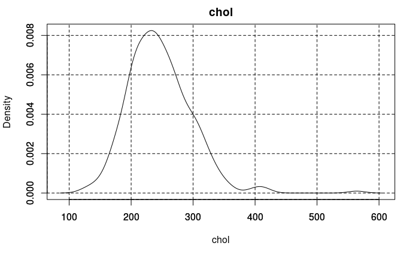

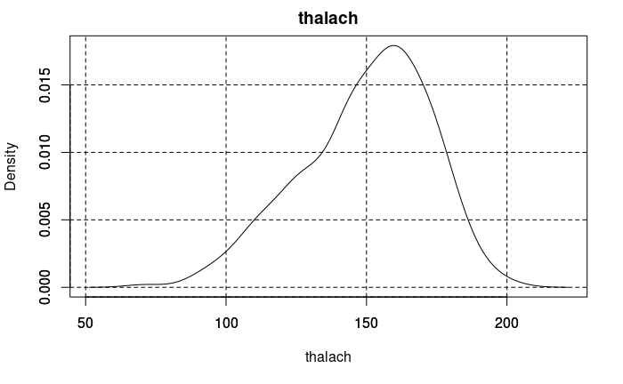

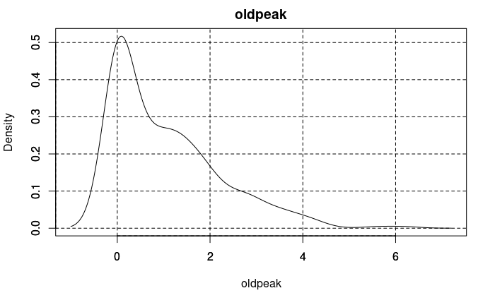

```r
for (i in c(1, 4, 5, 8, 10)) {
  plot(main=names(df)[i], density(df[, i]), xlab=names(df)[i])
  axis(1, tck=1, lty=2)
  axis(2, tck=1, lty=2)
}
```

Построили графики ядерных оценок для количесвтвенных признаков. Для качесвенных признаков нет смысла строить, так как они распределены по группам.

2. Реализовать анализ данных с помощью cdplot, dotchart, boxplot и stripchart.

Построим графики для признаков trestbps и cp, посмотрим, как распределёны значения trestbps в зависимости от значений cp.

cdplot

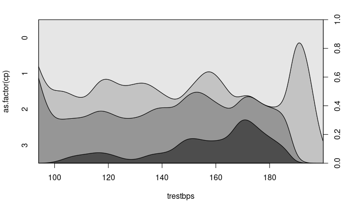

```r
cdplot(as.factor(cp) ~ trestbps, data=df)
```

cdpolt демонстрирует разное распределение признака trestbps в зависимости от значения переменной cp.

boxplot

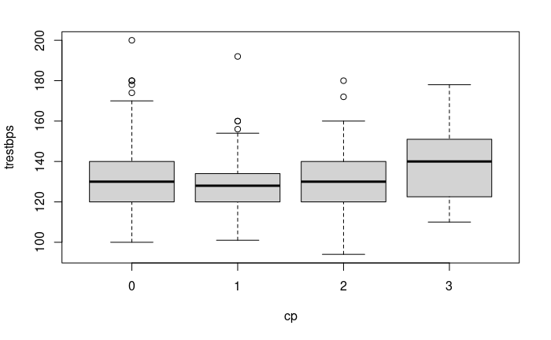

```r
boxplot(trestbps ~ cp, data=df)
```

boxplot показывают неоднородность в распределении признаков.

dotchart

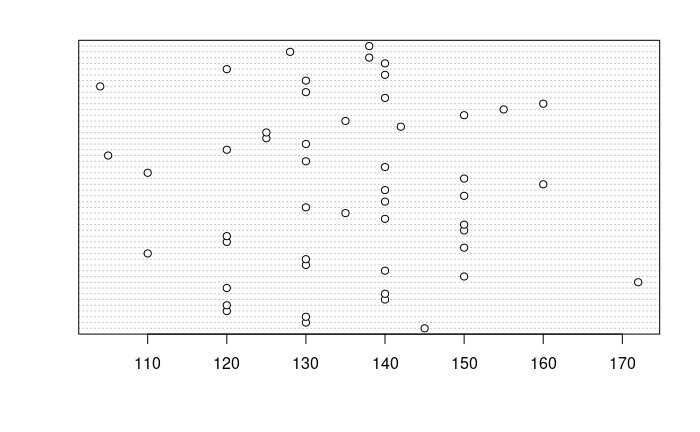

```r
dotchart(df$trestbps[1:50])
```

dotchart демонстрируют неоднородность в распределении признаков.

stripchart

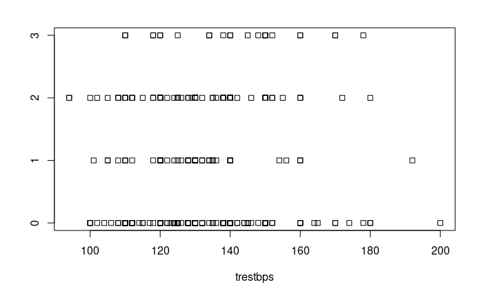

```r
stripchart(trestbps ~ cp, data=df)
```

stripchart демонстрируют неоднородность в распределении признаков.

3. Проверить, являются ли наблюдения выбросами с точки зрения формальных статистических критериев Граббса и Q-теста Диксона. Визуализировать результаты.

Создадим массив с двумя выбросами и применим к нему тесты Граббса и Диксона.

```r
chol_ = sort(df$chol)
chol <- c(chol_[1], chol_[140:160], chol_[300])
```

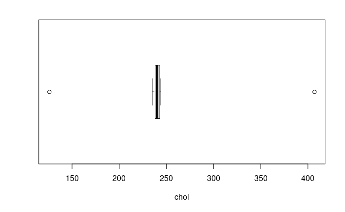

```r
boxplot(chol, xlab='chol', outline=T, horizontal=T)
```

Критерий Граббса

```r
grubbs.test(chol, type=11)
```

```
    Grubbs test for two opposite outliers

data:  chol
G = 6.5150193, U = 0.0038839, p-value < 2.2e-16
alternative hypothesis: 126 and 407 are outliers
```

Критерий Диксона

```r
dixon.test(chol, type=0, opposite=FALSE, two.sided=TRUE)
```

```
    Dixon test for outliers

data:  chol
Q = 0.95322, p-value < 2.2e-16
alternative hypothesis: highest value 407 is an outlier
```

4. Воспользоваться инструментами для заполнения пропусков в данных. Пропуски внести вручную и сравнить результаты заполнения с истинными значениями.

```r
original <- df$trestbps
miss <- original
missing_indexes = sample(1:length(df), round(length(df) * 0.1))
```

Заполним средним

```r
miss[missing_indexes] <- NA
miss[missing_indexes] <- mean(miss, na.rm = T)

print('Metrics in mean case:')
```

```
[1] "Metrics in mean case:"
```

```r
actuals <- original[missing_indexes]
predicteds <- miss[missing_indexes]
mean(c((actuals - predicteds)**2))**0.5
```

```
[1] 13.42053
```

Заполним медианой

```r
miss[missing_indexes] <- NA
miss[missing_indexes] <- median(miss, na.rm = T)

print('Metrics in median case:')
```

```
[1] "Metrics in median case:"
```

```r
actuals <- original[missing_indexes]
predicteds <- miss[missing_indexes]
mean(c((actuals - predicteds)**2))**0.5
```

```
[1] 15
```

В целом, в обоих методах получили схожие значение ошибки заполнения данных, но при заполнении средним чуть лучше.

5. Сгенерировать данные из нормального распределения с различными параметрами и провести анализ с помощью графиков эмпирических функций распределений, квантилей, метода огибающих, а также стандартных процедур проверки гипотез о нормальности (критерии Колмогорова-Смирнова, ШапироУилка, Андерсона-Дарлинга, Крамера фон Мизеса, Колмогорова-Смирнова в модификации Лиллиефорса и Шапиро-Франсия). Рассмотреть выборки малого и умеренного объемов.

Функции для исследования

Эмпирические функции распределения

```r
f_cdf <- function(data, title) {
  data_ <- fitdistr(data, densfun='normal')
  par(mfrow=c(1, 1), pty='s')
  plot(data, pnorm(data, mean=data_$estimate[1], sd=data_$estimate[2]),
       type='l', col='blue', lwd=2, xlab=title, ylab='')
  plot(ecdf(data), add=T, col='black')
}
```

Метод огибающих

```r
f_env <- function(data, title) {
  par(mfrow=c(1, 1), pty='s')
  z <- (data - mean(data)) / sqrt(var(data))  #Стандартизация выборки
  x.qq <- qqnorm(z, plot.it=FALSE)
  x.qq <- lapply(x.qq, sort)
  plot(x.qq, ylim = c(-5, 5), ylab="Z-статистики выборки", xlab=title, col='red')

  x.gen <- function(dat, mle) rnorm(length(dat))
  x.qqboot <- boot(z, sort, R=999,
                   sim='parametric', ran.gen=x.gen)
  sapply(1:999, function(i) lines(x.qq$x, x.qqboot$t[i,],
                                 type='l', col='grey'))
  points(x.qq, pch=20)
  lines(c(-3, 3), c(-3, 3), col='red', lwd=2)

  x.env <- envelope(x.qqboot, level=0.9)
  lines(x.qq$x,x.env$point[1, ], lty = 4)
  lines(x.qq$x,x.env$point[2, ], lty = 4)
  lines(x.qq$x,x.env$overall[1, ], lty = 1)
  lines(x.qq$x,x.env$overall[2, ], lty = 1)
}
```

Генерируем N(0, 1) n = 50 N(0, 1) n = 5000 N(7, 3) n = 50 N(7, 3) n = 5000

```r
n = 50
data_50 <- matrix(c(sort(rnorm(n, mean = 0, sd = 1)),
                 sort(rnorm(n, mean = 7, sd = 3))),
               nrow = 2, ncol = n, byrow = TRUE)

n = 5000
data_5000 <- matrix(c(sort(rnorm(n, mean = 0, sd = 1)),
                    sort(rnorm(n, mean = 7, sd = 3))),
                  nrow = 2, ncol = n, byrow = TRUE)
```

Эмпирические функции распределения

N(0, 1)

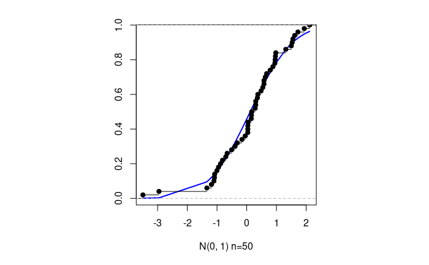

```r
f_cdf(data_50[1,], 'N(0, 1) n=50')
```

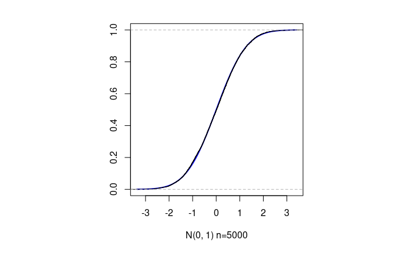

```r
f_cdf(data_5000[1,], 'N(0, 1) n=5000')
```

N(7, 3)

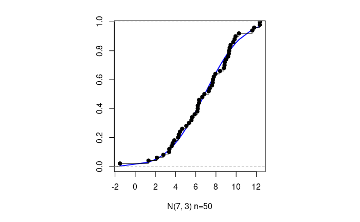

```r
f_cdf(data_50[2,], 'N(7, 3) n=50')
```

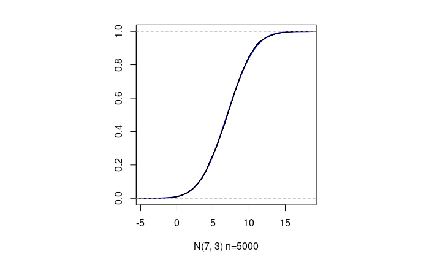

```r
f_cdf(data_5000[2,], 'N(7, 3) n=5000')
```

Функции распределения для разных распределений повторяют друг друга с точностью до масштаба. При увеличении количества объектов функция распрделения становиться более гладкой.

Квантили

N(0, 1)

```r
par(mfrow=c(1, 1), pty='s')
qqnorm(data_50[1,])
qqline(data_50[1,])
```

[figure not shown]

```r
par(mfrow=c(1, 1), pty='s')
```

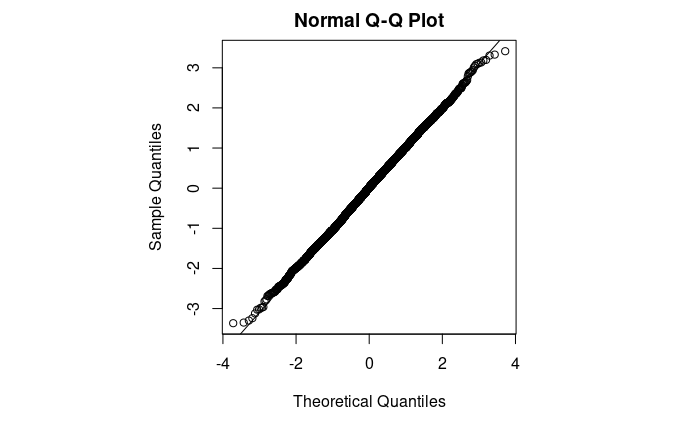

```r
qqnorm(data_5000[1,])
qqline(data_5000[1,])
```

N(7, 3)

```r
par(mfrow=c(1, 1), pty='s')
qqnorm(data_50[2,])
qqline(data_50[2,])
```

[figure not shown]

```r
par(mfrow=c(1, 1), pty='s')
```

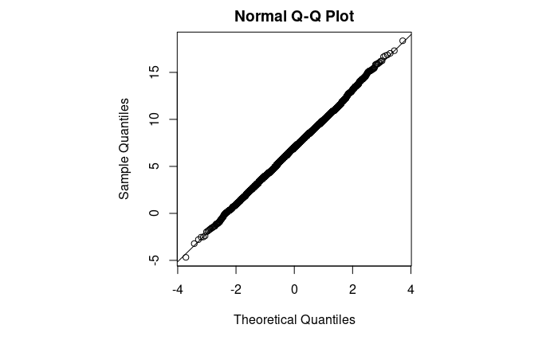

```r
qqnorm(data_5000[2,])
qqline(data_5000[2,])
```

Подобно графикам функций распределения: при увеличении числа элементов выборки график становиться более гладким.

Метод огибающих

N(0, 1)

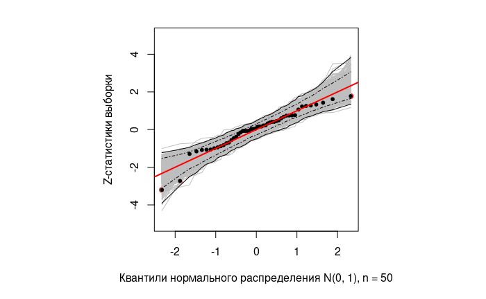

```r
f_env(data_50[1,], 'Квантили нормального распределения N(0, 1), n = 50')
```

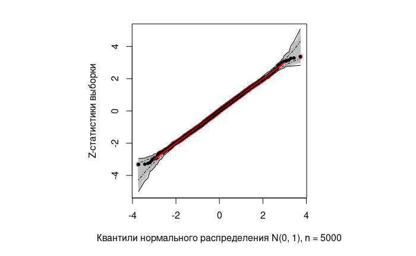

```r
f_env(data_5000[1,], 'Квантили нормального распределения N(0, 1), n = 5000')
```

N(7, 3)

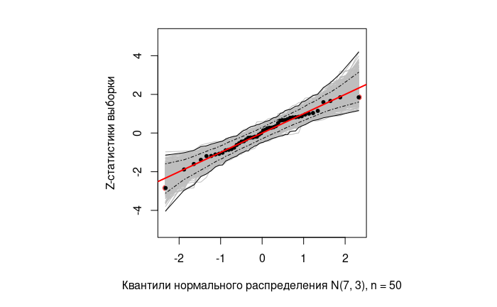

```r
f_env(data_50[2,], 'Квантили нормального распределения N(7, 3), n = 50')
```

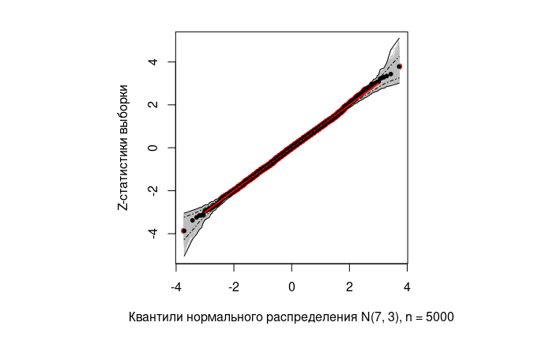

```r
f_env(data_5000[2,], 'Квантили нормального распределения N(7, 3), n = 5000')
```

По данному тесту выборка удовлетворяет нормальному распределению.

Процедуры проверки гипотез о нормальности

N(0, 1)

Критерий Колмогорова-Смирнова

```r
data_50_ <- fitdistr(data_50[1,], densfun='normal')
ks.test(data_50[1,], pnorm, mean=data_50_$estimate[1], sd=data_50_$estimate[2])
```

```
    Exact one-sample Kolmogorov-Smirnov test

data:  data_50[1, ]
D = 0.11087, p-value = 0.5339
alternative hypothesis: two-sided
```

```r
data_5000_ <- fitdistr(data_5000[1,], densfun='normal')
ks.test(data_5000[1,], pnorm, mean=data_5000_$estimate[1], sd=data_5000_$estimate[2])
```

```
    Asymptotic one-sample Kolmogorov-Smirnov test

data:  data_5000[1, ]
D = 0.010638, p-value = 0.6234
alternative hypothesis: two-sided
```

Критерий Шапиров-Уилка

```r
shapiro.test(data_50[1,])
```

```
    Shapiro-Wilk normality test

data:  data_50[1, ]
W = 0.94851, p-value = 0.02963
```

```r
shapiro.test(data_5000[1,])
```

```
    Shapiro-Wilk normality test

data:  data_5000[1, ]
W = 0.99956, p-value = 0.326
```

Критерий Андерсона-Дарлинга

```r
ad.test(data_50[1,])
```

```
    Anderson-Darling normality test

data:  data_50[1, ]
A = 0.53911, p-value = 0.1589
```

```r
ad.test(data_5000[1,])
```

```
    Anderson-Darling normality test

data:  data_5000[1, ]
A = 0.51197, p-value = 0.1949
```

Критерий Крамера фон Мизеса

```r
cvm.test(data_50[1,])
```

```
    Cramer-von Mises normality test

data:  data_50[1, ]
W = 0.070447, p-value = 0.2702
```

```r
cvm.test(data_5000[1,])
```

```
    Cramer-von Mises normality test

data:  data_5000[1, ]
W = 0.081697, p-value = 0.197
```

Критерий Колмогорова-Смирнова в модификации Лиллиефорса

```r
lillie.test(data_50[1,])
```

```
    Lilliefors (Kolmogorov-Smirnov) normality test

data:  data_50[1, ]
D = 0.11117, p-value = 0.1274
```

```r
lillie.test(data_5000[1,])
```

```
    Lilliefors (Kolmogorov-Smirnov) normality test

data:  data_5000[1, ]
D = 0.010614, p-value = 0.1881
```

Критерий Шапиро-Франсия

```r
sf.test(data_50[1,])
```

```
    Shapiro-Francia normality test

data:  data_50[1, ]
W = 0.94451, p-value = 0.02238
```

```r
sf.test(data_5000[1,])
```

```
    Shapiro-Francia normality test

data:  data_5000[1, ]
W = 0.99964, p-value = 0.4528
```

N(7, 3)

Критерий Колмогорова-Смирнова

```r
ks.test(data_50[2, ],pnorm, mean = data_mle_50_2$estimate[1], sd = data_mle_50_2$estimate[2])
```

```
    Exact one-sample Kolmogorov-Smirnov test

data:  data_50[2, ]
D = 0.098036, p-value = 0.6858
alternative hypothesis: two-sided
```

```r
ks.test(data_5000[2, ],pnorm, mean = data_mle_5000_2$estimate[1], sd = data_mle_5000_2$estimate[2])
```

```
    Asymptotic one-sample Kolmogorov-Smirnov test

data:  data_5000[2, ]
D = 0.0099853, p-value = 0.7011
alternative hypothesis: two-sided
```

Критерий Шапиров-Уилка

```r
shapiro.test(data_50[2,])
```

```
    Shapiro-Wilk normality test

data:  data_50[2, ]
W = 0.98208, p-value = 0.6426
```

```r
shapiro.test(data_5000[2,])
```

```
    Shapiro-Wilk normality test

data:  data_5000[2, ]
W = 0.99956, p-value = 0.3307
```

Критерий Андерсона-Дарлинга

```r
ad.test(data_50[2,])
```

```
    Anderson-Darling normality test

data:  data_50[2, ]
A = 0.23731, p-value = 0.7733
```

```r
ad.test(data_5000[2,])
```

```
    Anderson-Darling normality test

data:  data_5000[2, ]
A = 0.51229, p-value = 0.1946
```

Критерий Крамера фон Мизеса

```r
cvm.test(data_50[2,])
```

```
    Cramer-von Mises normality test

data:  data_50[2, ]
W = 0.034457, p-value = 0.7746
```

```r
cvm.test(data_5000[2,])
```

```
    Cramer-von Mises normality test

data:  data_5000[2, ]
W = 0.069135, p-value = 0.287
```

Критерий Колмогорова-Смирнова в модификации Лиллиефорса

```r
lillie.test(data_50[2,])
```

```
    Lilliefors (Kolmogorov-Smirnov) normality test

data:  data_50[2, ]
D = 0.080312, p-value = 0.5814
```

```r
lillie.test(data_5000[2,])
```

```
    Lilliefors (Kolmogorov-Smirnov) normality test

data:  data_5000[2, ]
D = 0.0092793, p-value = 0.3723
```

Критерий Шапиро-Франсия

```r
sf.test(data_50[2,])
```

```
    Shapiro-Francia normality test

data:  data_50[2, ]
W = 0.98213, p-value = 0.5537
```

```r
sf.test(data_5000[2,])
```

```
    Shapiro-Francia normality test

data:  data_5000[2, ]
W = 0.99956, p-value = 0.2532
```

Для всех критериев значение p-value больше критического значение 0.05 у нормального рапределения N(7, 3), селедовательно принимаем гипотезу о нормальности данных.

6. Продемонстрировать пример анализа данных с помощью графиков квантилей, метода огибающих, а также стандартных процедур проверки гипотез о нормальности. Рассмотреть выборки малого и умеренного объемов.

Будем рассматривать данные из колонки trestbps, так как ее график наиболее схож с графиком нормального распределения. Возьмём выборку из 50 элементов и все данные.

```r
trestbps_50 <- df$trestbps[1:50]
trestbps <- df$trestbps
```

Эмпирическая функция распределения

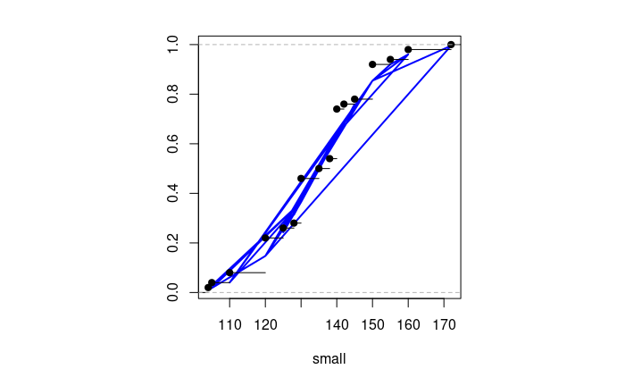

```r
f_cdf(trestbps_50, 'small')
```

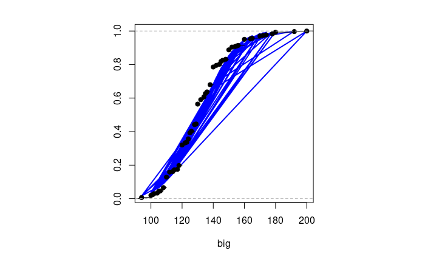

```r
f_cdf(trestbps, 'big')
```

Квантили

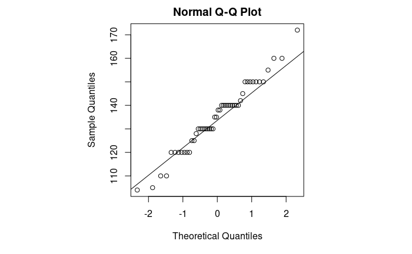

```r
par(mfrow=c(1, 1), pty='s')

qqnorm(trestbps_50)
qqline(trestbps_50)
```

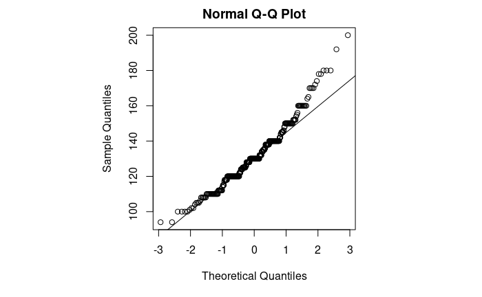

```r
qqnorm(trestbps)
qqline(trestbps)
```

Метод огибающих

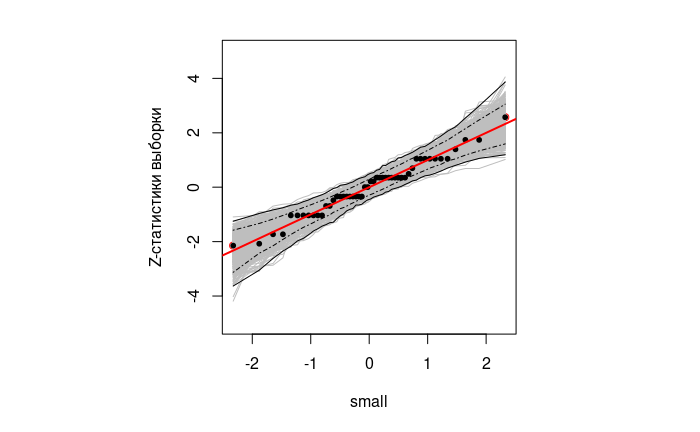

```r
f_env(trestbps_50, 'small')
```

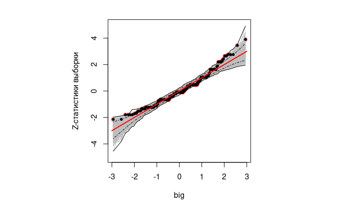

```r
f_env(trestbps, 'big')
```

Процедуры проверки гипотез о нормальности

Критерий Колмогорова-Смирнова

```r
trestbps_50_ <- fitdistr(trestbps_50, densfun='normal')
ks.test(unique(trestbps_50), pnorm, mean=trestbps_50_$estimate[1], sd=trestbps_50_$estimate[2])
```

```
    Exact one-sample Kolmogorov-Smirnov test

data:  unique(trestbps_50)
D = 0.14732, p-value = 0.8298
alternative hypothesis: two-sided
```

```r
trestbps_ <- fitdistr(trestbps, densfun='normal')
ks.test(unique(trestbps), pnorm, mean=trestbps_$estimate[1], sd=trestbps_$estimate[2])
```

```
    Exact one-sample Kolmogorov-Smirnov test

data:  unique(trestbps)
D = 0.16468, p-value = 0.125
alternative hypothesis: two-sided
```

Критерий Шапиров-Уилка

```r
shapiro.test(trestbps_50)
```

```
    Shapiro-Wilk normality test

data:  trestbps_50
W = 0.97529, p-value = 0.3744
```

```r
shapiro.test(trestbps)
```

```
    Shapiro-Wilk normality test

data:  trestbps
W = 0.96592, p-value = 1.458e-06
```

Критерий Андерсона-Дарлинга

```r
ad.test(trestbps_50)
```

```
    Anderson-Darling normality test

data:  trestbps_50
A = 0.55542, p-value = 0.1443
```

```r
ad.test(trestbps)
```

```
    Anderson-Darling normality test

data:  trestbps
A = 2.5717, p-value = 1.673e-06
```

Критерий Крамера фон Мизеса

```r
cvm.test(trestbps_50)
```

```
    Cramer-von Mises normality test

data:  trestbps_50
W = 0.098563, p-value = 0.1141
```

```r
cvm.test(trestbps)
```

```
    Cramer-von Mises normality test

data:  trestbps
W = 0.41586, p-value = 1.799e-05
```

Критерий Колмогорова-Смирнова в модификации Лиллиефорса

```r
lillie.test(trestbps_50)
```

```
    Lilliefors (Kolmogorov-Smirnov) normality test

data:  trestbps_50
D = 0.10271, p-value = 0.2082
```

```r
lillie.test(trestbps)
```

```
    Lilliefors (Kolmogorov-Smirnov) normality test

data:  trestbps
D = 0.10195, p-value = 4.683e-08
```

Критерий Шапиро-Франсия

```r
sf.test(trestbps_50)
```

```
    Shapiro-Francia normality test

data:  trestbps_50
W = 0.97483, p-value = 0.3041
```

```r
sf.test(trestbps)
```

```
    Shapiro-Francia normality test

data:  trestbps
W = 0.96554, p-value = 4.873e-06
```

7. Продемонстрировать применение для проверки различных гипотез и различных доверительных уровней (0.9, 0.95, 0.99) следующих критериев:
1. Стьюдента, включая односторонние варианты, когда проверяемая нулевая гипотеза заключается в том, что одно из сравниваемых средних значений больше (или меньше) другого. Реализовать оценку мощности критериев при заданном объеме выборки или определения объема выборки для достижения заданной мощности;
2. Уилкоксона-Манна-Уитни (ранговые);
3. Фишера, Левене, Бартлетта, Флигнера-Килина (проверка гипотез об однородности дисперсий).

```r
trestbps <- df$trestbps
thalach <- df$thalach
```

Тест Стьюдента Будем рассматривать данные по колонкам trestbps и thalach, так как у них более менее схожие параметры.

```r
for (a in c(0.9, 0.95, 0.99)){
  print(t.test(trestbps, thalach, conf.level=a, alternative='t'))
  print(t.test(trestbps, thalach, conf.level=a, alternative='l'))
  print(t.test(trestbps, thalach, conf.level=a, alternative='g'))
}
```

```
    Welch Two Sample t-test

data:  trestbps and thalach
t = -10.875, df = 565.53, p-value < 2.2e-16
alternative hypothesis: true difference in means is not equal to 0
90 percent confidence interval:
 -20.75359 -15.29261
sample estimates:
mean of x mean of y
 131.6238  149.6469


    Welch Two Sample t-test

data:  trestbps and thalach
t = -10.875, df = 565.53, p-value < 2.2e-16
alternative hypothesis: true difference in means is less than 0
90 percent confidence interval:
     -Inf -15.8967
sample estimates:
mean of x mean of y
 131.6238  149.6469


    Welch Two Sample t-test

data:  trestbps and thalach
t = -10.875, df = 565.53, p-value = 1
alternative hypothesis: true difference in means is greater than 0
90 percent confidence interval:
 -20.1495      Inf
sample estimates:
mean of x mean of y
 131.6238  149.6469


    Welch Two Sample t-test

data:  trestbps and thalach
t = -10.875, df = 565.53, p-value < 2.2e-16
```

[output cut: 51 more lines]

```
sample estimates:
mean of x mean of y
 131.6238  149.6469


    Welch Two Sample t-test

data:  trestbps and thalach
t = -10.875, df = 565.53, p-value = 1
alternative hypothesis: true difference in means is greater than 0
99 percent confidence interval:
 -21.88952       Inf
sample estimates:
mean of x mean of y
 131.6238  149.6469
```

Принимаем гипотезу о том, что среднее параметра trestbps меньше среднего параметра thalach.

```r
trestbps_h <- unique(df$trestbps)[1:24]
trestbps_t <- unique(df$trestbps)[25:49]
```

```r
for (a in c(0.9, 0.95, 0.99)){
  print(wilcox.test(trestbps_h, trestbps_t, conf.level=a, alternative='t'))
  print(wilcox.test(trestbps_h, trestbps_t, conf.level=a, alternative='l'))
  print(wilcox.test(trestbps_h, trestbps_t, conf.level=a, alternative='g'))
}
```

```
    Wilcoxon rank sum exact test

data:  trestbps_h and trestbps_t
W = 196, p-value = 0.03765
alternative hypothesis: true location shift is not equal to 0


    Wilcoxon rank sum exact test

data:  trestbps_h and trestbps_t
W = 196, p-value = 0.01882
alternative hypothesis: true location shift is less than 0


    Wilcoxon rank sum exact test

data:  trestbps_h and trestbps_t
W = 196, p-value = 0.9821
alternative hypothesis: true location shift is greater than 0


    Wilcoxon rank sum exact test

data:  trestbps_h and trestbps_t
W = 196, p-value = 0.03765
alternative hypothesis: true location shift is not equal to 0


    Wilcoxon rank sum exact test

data:  trestbps_h and trestbps_t
W = 196, p-value = 0.01882
alternative hypothesis: true location shift is less than 0


    Wilcoxon rank sum exact test

data:  trestbps_h and trestbps_t
W = 196, p-value = 0.9821
alternative hypothesis: true location shift is greater than 0


    Wilcoxon rank sum exact test

data:  trestbps_h and trestbps_t
W = 196, p-value = 0.03765
alternative hypothesis: true location shift is not equal to 0


    Wilcoxon rank sum exact test

data:  trestbps_h and trestbps_t
W = 196, p-value = 0.01882
alternative hypothesis: true location shift is less than 0


    Wilcoxon rank sum exact test

data:  trestbps_h and trestbps_t
W = 196, p-value = 0.9821
alternative hypothesis: true location shift is greater than 0
```

```r
trestbps_h <- unique(df$trestbps)[1:30]
thalach_h <- unique(df$thalach)[1:30]
data <- data.frame(xy=c(trestbps_h, thalach_h), det=c(rep("x", length(trestbps_h)), rep("y", length(thalach_h))))
```

```r
print(var.test(xy ~ det, data=data))
```

```
    F test to compare two variances

data:  xy by det
F = 1.1993, num df = 29, denom df = 29, p-value = 0.6278
alternative hypothesis: true ratio of variances is not equal to 1
95 percent confidence interval:
 0.570829 2.519744
sample estimates:
ratio of variances
          1.199309
```

```r
#print(leveneTest(xy ~ det, data=data))
print(fligner.test(xy ~ det, data=data))
```

```
    Fligner-Killeen test of homogeneity of variances

data:  xy by det
Fligner-Killeen:med chi-squared = 0.55143, df = 1, p-value = 0.4577
```

```r
print(bartlett.test(xy ~ det, data=data))
```

```
    Bartlett test of homogeneity of variances

data:  xy by det
Bartlett's K-squared = 0.2351, df = 1, p-value = 0.6278
```

8. Исследовать корреляционные взаимосвязи в данных с помощью коэффициентов корреляции Пирсона, Спирмена и Кендалла.

корреляции Пирсона

```r
round(cor(df, method = 'pearson'), 2)
```

```
           age   sex    cp trestbps  chol   fbs restecg thalach exang oldpeak slope    ca  thal target
age       1.00 -0.10 -0.07     0.28  0.21  0.12   -0.12   -0.40  0.10    0.21 -0.17  0.28  0.07  -0.23
sex      -0.10  1.00 -0.05    -0.06 -0.20  0.05   -0.06   -0.04  0.14    0.10 -0.03  0.12  0.21  -0.28
cp       -0.07 -0.05  1.00     0.05 -0.08  0.09    0.04    0.30 -0.39   -0.15  0.12 -0.18 -0.16   0.43
trestbps  0.28 -0.06  0.05     1.00  0.12  0.18   -0.11   -0.05  0.07    0.19 -0.12  0.10  0.06  -0.14
chol      0.21 -0.20 -0.08     0.12  1.00  0.01   -0.15   -0.01  0.07    0.05  0.00  0.07  0.10  -0.09
fbs       0.12  0.05  0.09     0.18  0.01  1.00   -0.08   -0.01  0.03    0.01 -0.06  0.14 -0.03  -0.03
restecg  -0.12 -0.06  0.04    -0.11 -0.15 -0.08    1.00    0.04 -0.07   -0.06  0.09 -0.07 -0.01   0.14
thalach  -0.40 -0.04  0.30    -0.05 -0.01 -0.01    0.04    1.00 -0.38   -0.34  0.39 -0.21 -0.10   0.42
exang     0.10  0.14 -0.39     0.07  0.07  0.03   -0.07   -0.38  1.00    0.29 -0.26  0.12  0.21  -0.44
oldpeak   0.21  0.10 -0.15     0.19  0.05  0.01   -0.06   -0.34  0.29    1.00 -0.58  0.22  0.21  -0.43
slope    -0.17 -0.03  0.12    -0.12  0.00 -0.06    0.09    0.39 -0.26   -0.58  1.00 -0.08 -0.10   0.35
ca        0.28  0.12 -0.18     0.10  0.07  0.14   -0.07   -0.21  0.12    0.22 -0.08  1.00  0.15  -0.39
thal      0.07  0.21 -0.16     0.06  0.10 -0.03   -0.01   -0.10  0.21    0.21 -0.10  0.15  1.00  -0.34
target   -0.23 -0.28  0.43    -0.14 -0.09 -0.03    0.14    0.42 -0.44   -0.43  0.35 -0.39 -0.34   1.00
```

корреляции Спирмена

```r
round(cor(df, method = 'spearman'), 2)
```

```
           age   sex    cp trestbps  chol   fbs restecg thalach exang oldpeak slope    ca  thal target
age       1.00 -0.10 -0.09     0.29  0.20  0.11   -0.13   -0.40  0.09    0.27 -0.18  0.34  0.09  -0.24
sex      -0.10  1.00 -0.06    -0.05 -0.15  0.05   -0.05   -0.04  0.14    0.10 -0.03  0.12  0.25  -0.28
cp       -0.09 -0.06  1.00     0.04 -0.09  0.09    0.07    0.32 -0.42   -0.16  0.16 -0.22 -0.21   0.46
trestbps  0.29 -0.05  0.04     1.00  0.13  0.15   -0.13   -0.04  0.05    0.15 -0.09  0.09  0.06  -0.12
chol      0.20 -0.15 -0.09     0.13  1.00  0.02   -0.16   -0.05  0.09    0.05 -0.01  0.11  0.08  -0.12
fbs       0.11  0.05  0.09     0.15  0.02  1.00   -0.08   -0.01  0.03    0.03 -0.05  0.13 -0.01  -0.03
restecg  -0.13 -0.05  0.07    -0.13 -0.16 -0.08    1.00    0.09 -0.08   -0.08  0.11 -0.10 -0.01   0.15
thalach  -0.40 -0.04  0.32    -0.04 -0.05 -0.01    0.09    1.00 -0.40   -0.43  0.44 -0.26 -0.16   0.43
exang     0.09  0.14 -0.42     0.05  0.09  0.03   -0.08   -0.40  1.00    0.30 -0.27  0.16  0.25  -0.44
oldpeak   0.27  0.10 -0.16     0.15  0.05  0.03   -0.08   -0.43  0.30    1.00 -0.59  0.22  0.26  -0.42
slope    -0.18 -0.03  0.16    -0.09 -0.01 -0.05    0.11    0.44 -0.27   -0.59  1.00 -0.10 -0.15   0.37
ca        0.34  0.12 -0.22     0.09  0.11  0.13   -0.10   -0.26  0.16    0.22 -0.10  1.00  0.19  -0.46
thal      0.09  0.25 -0.21     0.06  0.08 -0.01   -0.01   -0.16  0.25    0.26 -0.15  0.19  1.00  -0.40
target   -0.24 -0.28  0.46    -0.12 -0.12 -0.03    0.15    0.43 -0.44   -0.42  0.37 -0.46 -0.40   1.00
```

корреляции Кендалла

```r
round(cor(df, method = 'kendall'), 2)
```

```
           age   sex    cp trestbps  chol   fbs restecg thalach exang oldpeak slope    ca  thal target
age       1.00 -0.08 -0.07     0.20  0.14  0.09   -0.11   -0.28  0.07    0.19 -0.15  0.27  0.07  -0.20
sex      -0.08  1.00 -0.06    -0.04 -0.12  0.05   -0.05   -0.03  0.14    0.09 -0.02  0.11  0.24  -0.28
cp       -0.07 -0.06  1.00     0.03 -0.07  0.08    0.06    0.25 -0.39   -0.13  0.15 -0.19 -0.19   0.43
trestbps  0.20 -0.04  0.03     1.00  0.09  0.13   -0.11   -0.03  0.04    0.11 -0.07  0.07  0.05  -0.10
chol      0.14 -0.12 -0.07     0.09  1.00  0.02   -0.13   -0.03  0.08    0.04 -0.01  0.09  0.07  -0.10
fbs       0.09  0.05  0.08     0.13  0.02  1.00   -0.08   -0.01  0.03    0.02 -0.04  0.13 -0.01  -0.03
restecg  -0.11 -0.05  0.06    -0.11 -0.13 -0.08    1.00    0.07 -0.08   -0.07  0.11 -0.09 -0.01   0.15
thalach  -0.28 -0.03  0.25    -0.03 -0.03 -0.01    0.07    1.00 -0.33   -0.31  0.35 -0.20 -0.13   0.35
exang     0.07  0.14 -0.39     0.04  0.08  0.03   -0.08   -0.33  1.00    0.26 -0.27  0.15  0.24  -0.44
oldpeak   0.19  0.09 -0.13     0.11  0.04  0.02   -0.07   -0.31  0.26    1.00 -0.51  0.18  0.21  -0.36
slope    -0.15 -0.02  0.15    -0.07 -0.01 -0.04    0.11    0.35 -0.27   -0.51  1.00 -0.09 -0.15   0.36
ca        0.27  0.11 -0.19     0.07  0.09  0.13   -0.09   -0.20  0.15    0.18 -0.09  1.00  0.17  -0.43
thal      0.07  0.24 -0.19     0.05  0.07 -0.01   -0.01   -0.13  0.24    0.21 -0.15  0.17  1.00  -0.39
target   -0.20 -0.28  0.43    -0.10 -0.10 -0.03    0.15    0.35 -0.44   -0.36  0.36 -0.43 -0.39   1.00
```

9. Продемонстрировать использование методов хи-квадрат, точного теста Фишера, теста МакНемара, Кохрана-Мантеля-Хензеля.

Метод хи-квадрат Проверим независимость колонок sex (пол) и target (наличие болезни).

```r
chisq.test(table(df$sex, df$target))
```

```
    Pearson's Chi-squared test with Yates' continuity correction

data:  table(df$sex, df$target)
X-squared = 22.717, df = 1, p-value = 1.877e-06
```

Отвергаем нулевую гипотезу о независимости пола и наличия болезни.

Точный тест Фишера Проверим независимость колонок sex (пол) и target (наличие болезни).

```r
fisher.test(table(df$sex, df$target))
```

```
    Fisher's Exact Test for Count Data

data:  table(df$sex, df$target)
p-value = 1.042e-06
alternative hypothesis: true odds ratio is not equal to 1
95 percent confidence interval:
 0.1519598 0.4783553
sample estimates:
odds ratio
 0.2731136
```

Отвергаем нулевую гипотезу о независимости пола и наличия болезни.

Тест МакНемара Проверим независимость колонок sex (пол) и target (наличие болезни).

```r
mcnemar.test(table(df$sex, df$target))
```

```
    McNemar's Chi-squared test with continuity correction

data:  table(df$sex, df$target)
McNemar's chi-squared = 9.0376, df = 1, p-value = 0.002645
```

Отвергаем нулевую гипотезу о независимости пола и наличия болезни.

Тест Кохрана-Мантеля-Хензеля Проверим независимость колонок sex (пол), target (наличие болезни) и exang (стенокардии, вызванной физической нагрузкой).

```r
data = table(df$target, df$sex, df$exang)

mantelhaen.test(data)
```

```
    Mantel-Haenszel chi-squared test with continuity correction

data:  data
Mantel-Haenszel X-squared = 16.889, df = 1, p-value = 3.963e-05
alternative hypothesis: true common odds ratio is not equal to 1
95 percent confidence interval:
 0.1527331 0.5088648
sample estimates:
common odds ratio
         0.278784
```

Следовательно отвергаем нулевую гипотезу о независимости пола, наличии болезни и стенокардии, вызванной физической нагрузкой.

10. Проверить наличие мультиколлинеарности в данных с помощью корреляционной матрицы и фактора инфляции дисперсии.

Корреляционная матрица

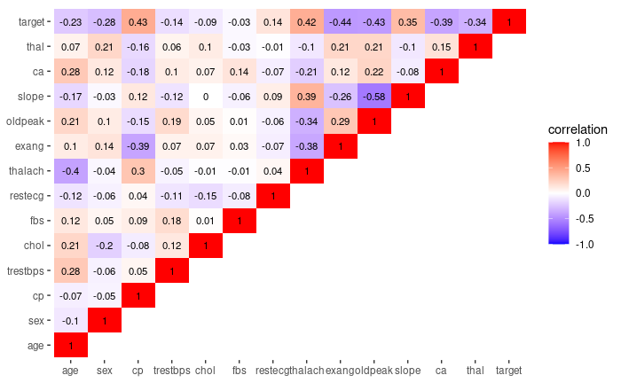

```r
get_upper_tri<-function(cormat){
  cormat[upper.tri(cormat)] <- NA
  return(cormat)
}

cormat <- round(cor(df, method = 'p'), 2)
upper_tri <- get_upper_tri(cormat)
melted_cormat <- melt(upper_tri, na.rm = TRUE)
ggplot(data = melted_cormat, aes(x=Var2, y=Var1, fill=value)) + geom_tile() +
  geom_text(aes(Var2, Var1, label = value), size = 3) +
  scale_fill_gradient2(low = "blue", high = "red", limit = c(-1,1), name="correlation") +
  theme(axis.title.x = element_blank(),
        axis.title.y = element_blank(),
        panel.background = element_blank())
```

Фактор инфляции дисперсии

На моей ЭВМ не запускалась функция vif(), поэтому исследование из онлайн интерпретатора с другими данными.

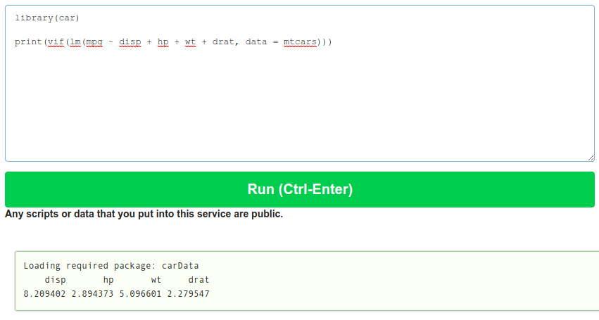

11. Исследовать зависимости в данных с помощью дисперсионного анализа.

```r
fit <- aov(target ~ ., data=df)
summary(fit)
```

```
             Df Sum Sq Mean Sq F value   Pr(>F)
age           1   3.82   3.819  30.444 7.64e-08 ***
sex           1   6.97   6.973  55.582 1.05e-12 ***
cp            1  12.19  12.189  97.161  < 2e-16 ***
trestbps      1   1.13   1.127   8.982 0.002964 **
chol          1   0.24   0.239   1.908 0.168210
fbs           1   0.01   0.006   0.047 0.827713
restecg       1   0.26   0.260   2.075 0.150829
thalach       1   4.40   4.396  35.038 9.15e-09 ***
exang         1   1.91   1.910  15.226 0.000119 ***
oldpeak       1   3.38   3.380  26.943 3.96e-07 ***
slope         1   0.23   0.234   1.862 0.173440
ca            1   2.96   2.962  23.611 1.94e-06 ***
thal          1   1.40   1.398  11.146 0.000952 ***
Residuals   289  36.26   0.125
---
Signif. codes:  0 ‘***’ 0.001 ‘**’ 0.01 ‘*’ 0.05 ‘.’ 0.1 ‘ ’ 1
```

Отвергаем нулевую гипотезу об отсутствии влияния признака на наличие болезни для age, sex, cp, trestbps, thalach, exang, oldpeak, ca, thal; Принимаем нулевую гипотезу для chol, fbs, restecg, slope. Для python получены другие результаты для chol, fbs, slope.

12. Подогнать регрессионные модели (в том числе, нелинейные) к данным, а также оценить качество подобной аппроксимации.

Попробуем предугадать значение trestbps (давление в состоянии покоя) от age (возраста).

автоподбор модели

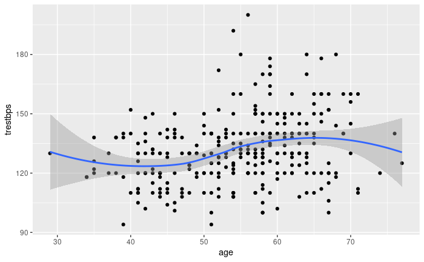

```r
ggplot(df, aes(x = age, y = trestbps)) + geom_point() +
  stat_smooth(method = "auto") +
  xlab("age") +
  ylab("trestbps")
```

линейная модель

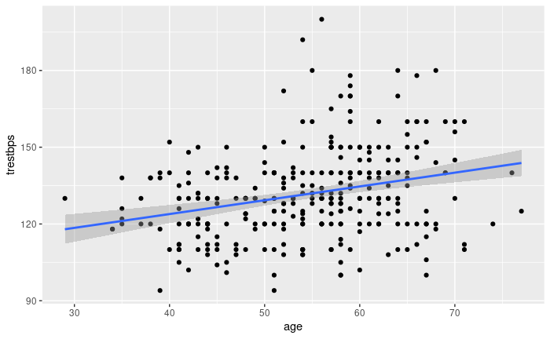

```r
ggplot(df, aes(x = age, y = trestbps)) + geom_point() +
  stat_smooth(method = "lm") +
  xlab("age") +
  ylab("trestbps")
```

```r
y <- df$trestbps
x <- df$age

M_reg <- lm(y ~ x)
summary(M_reg)
```

```
Call:
lm(formula = y ~ x)

Residuals:
    Min      1Q  Median      3Q     Max
-38.439 -11.499  -1.044  10.192  67.495

Coefficients:
            Estimate Std. Error t value Pr(>|t|)
(Intercept) 102.2961     5.8906  17.366  < 2e-16 ***
x             0.5394     0.1069   5.048 7.76e-07 ***
---
Signif. codes:  0 ‘***’ 0.001 ‘**’ 0.01 ‘*’ 0.05 ‘.’ 0.1 ‘ ’ 1

Residual standard error: 16.87 on 301 degrees of freedom
Multiple R-squared:  0.07804,   Adjusted R-squared:  0.07497
F-statistic: 25.48 on 1 and 301 DF,  p-value: 7.762e-07
```

```r
anova(M_reg)
```

```
Analysis of Variance Table

Response: y
           Df Sum Sq Mean Sq F value    Pr(>F)
x           1   7249  7248.9  25.477 7.762e-07 ***
Residuals 301  85642   284.5
---
Signif. codes:  0 ‘***’ 0.001 ‘**’ 0.01 ‘*’ 0.05 ‘.’ 0.1 ‘ ’ 1
```

нелинейная модель

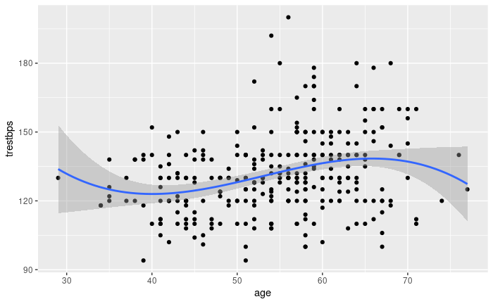

```r
ggplot(df, aes(x = age, y = trestbps)) + geom_point() +
  stat_smooth(method = "lm", formula = y~poly(x,3)) +
  xlab("age") +
  ylab("trestbps")
```

```r
y <- df$trestbps
x <- df$age

M_reg2 <- lm(y ~ poly(x,4))
summary(M_reg2)
```

```
Call:
lm(formula = y ~ poly(x, 4))

Residuals:
    Min      1Q  Median      3Q     Max
-38.472 -11.182  -1.723  11.063  66.675

Coefficients:
            Estimate Std. Error t value Pr(>|t|)
(Intercept) 131.6238     0.9651 136.384  < 2e-16 ***
poly(x, 4)1  85.1407    16.7994   5.068 7.07e-07 ***
poly(x, 4)2  -6.9858    16.7994  -0.416   0.6778
poly(x, 4)3 -38.5728    16.7994  -2.296   0.0224 *
poly(x, 4)4  -2.0784    16.7994  -0.124   0.9016
---
Signif. codes:  0 ‘***’ 0.001 ‘**’ 0.01 ‘*’ 0.05 ‘.’ 0.1 ‘ ’ 1

Residual standard error: 16.8 on 298 degrees of freedom
Multiple R-squared:  0.09463,   Adjusted R-squared:  0.08247
F-statistic: 7.786 on 4 and 298 DF,  p-value: 5.576e-06
```

```r
anova(M_reg2)
```

```
Analysis of Variance Table

Response: y
            Df Sum Sq Mean Sq F value    Pr(>F)
poly(x, 4)   4   8790 2197.48  7.7864 5.576e-06 ***
Residuals  298  84101  282.22
---
Signif. codes:  0 ‘***’ 0.001 ‘**’ 0.01 ‘*’ 0.05 ‘.’ 0.1 ‘ ’ 1
```

Построили три модели, получилось не очень хорошо (судя по точкам на графике и не могло получится хорошо). Наверно, влияет, что в выборке люди как с болезнью, так и без.

Вывод -Узнал о 12 статистических методах -Научился их применять с помощью языков Python и R -На R удобнее реализованы данные методы -Некоторые методы дают разные результаты в разных языках на одних и тех же данных -Интересно и полезно провёл время